# Your Digest for Tuesday, Sep 24, 2024 11:59 PM

# what I've learned on 2024-09-24

## Things to read

- causes of ncnc anaemia
- how to manage obesity - key steps
- how to screen for metabolic syndrome
- IgA nephropathy
- when to check blood glucose in order to optimize insulin dosing?
- [ ]

## 3 things you did well

## 3 things you can do better

# ECG quiz

[output not shown]

# Spinal cord injury

> Autonomic dysreflexia is a condition that emerges after a spinal cord injury, **usually when the damage has occurred above the T6 level**.

**Conus medullaris**: the tapering end of the spinal cord. Roots S5 to S 3 originate from it.

**Cauda Equina**: the collection of nervous running of the spinal cord to exit the lower vertebral foramina. Consists of roots L2 to S5.

## Cauda equina syndrome CES

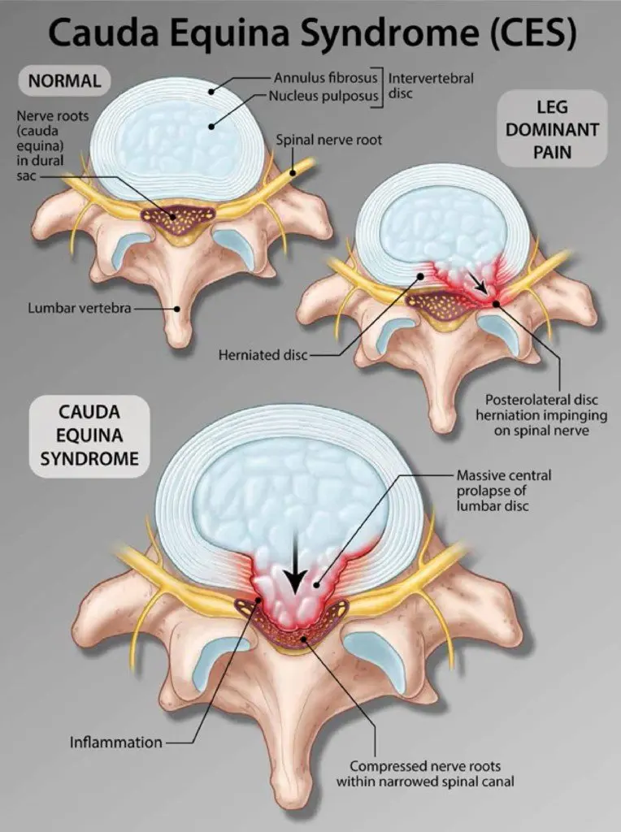

> - the cauda equina is the bundle of nerve roots distal to L1 (where the spinal cord ends) which extends beyond the end of the spinal cord. (I.e L2 to S5).  
>   - S2 to S4 provide *parasympathetic* afferents to the bladder, stimulating urination.
- CES be **acute** or **chronic**. (chronic CE will cause atrophy)

> See [here](https://emedicine.medscape.com/article/1148690-clinical#b1) for a comparison at Medscape
> - Conus medullaris syndrome (CMS) results when there is compressive damage to the spinal cord from T12-L2 vertebral levels.
> - In CMS, *knee jerk is preserved* and ankle jerk is lost. In CES, both are lost.

When to measure blood pressure  
3 days of measurements

- Two readings (back to back) before medication in the morning.
- and then two in the evening before going to bed before taking any evening medication.

Reducing sodium **and** *increasing potassium* (i.e fruits and vegetables) has significant benefits.

Losartan has a 4-6 hour half life. Technically it needs twice daily dosing.

The dose effect curve if antihypertensives flattens out at higher doses. So more adverse effects, less antihypertensive effects at higher doses.

Thiazides and precipitate gout. Starting dose for thiazides is 25mg.

ACEi and ARB will cause an upto 30% rise in serum creatinine and equivalent drop in eGFR but this is considered a feature of the drug actually working properly. It is thought to be minimising the *hyperfiltration* associated with hypertension, thus actually helping the kidneys at the expense of having and elevated creatinine. They can however cause *hyperkalemia*. Potassium binders can be used to counter this.  
A higher rise in creatinine could indicate a non diabetes cause of CKD like renal artery stenosis.

Diuretics can also be used in CKD.

The CLICK trial:  
Patients with CKD were given chlorthalidone and it worked very well. Previously we thought that thiazides don't work in CKD but it has been shown that they do. Loop diuretics also work as antihypertensives in CKD.

Hydralazine is a potent vasodilator. It's a last line antihypertensive.